# Project: Identify Customer Segments

In this project, you will apply unsupervised learning techniques to identify segments of the population that form the core customer base for a mail-order sales company in Germany. These segments can then be used to direct marketing campaigns towards audiences that will have the highest expected rate of returns. The data that you will use has been provided by our partners at Bertelsmann Arvato Analytics, and represents a real-life data science task.

This notebook will help you complete this task by providing a framework within which you will perform your analysis steps. In each step of the project, you will see some text describing the subtask that you will perform, followed by one or more code cells for you to complete your work. **Feel free to add additional code and markdown cells as you go along so that you can explore everything in precise chunks.** The code cells provided in the base template will outline only the major tasks, and will usually not be enough to cover all of the minor tasks that comprise it.

It should be noted that while there will be precise guidelines on how you should handle certain tasks in the project, there will also be places where an exact specification is not provided. **There will be times in the project where you will need to make and justify your own decisions on how to treat the data.** These are places where there may not be only one way to handle the data. In real-life tasks, there may be many valid ways to approach an analysis task. One of the most important things you can do is clearly document your approach so that other scientists can understand the decisions you've made.

At the end of most sections, there will be a Markdown cell labeled **Discussion**. In these cells, you will report your findings for the completed section, as well as document the decisions that you made in your approach to each subtask. **Your project will be evaluated not just on the code used to complete the tasks outlined, but also your communication about your observations and conclusions at each stage.**

```python
# import libraries here; add more as necessary
import numpy as np
import pandas as pd
import matplotlib.pyplot as plt
import seaborn as sns
from sklearn.preprocessing import OneHotEncoder
from sklearn.preprocessing import Imputer
from sklearn.preprocessing import StandardScaler
from sklearn.decomposition import PCA
from sklearn.cluster import KMeans, MiniBatchKMeans
import time

# magic word for producing visualizations in notebook
%matplotlib inline

'''
Import note: The classroom currently uses sklearn version 0.19.
If you need to use an imputer, it is available in sklearn.preprocessing.Imputer,
instead of sklearn.impute as in newer versions of sklearn.
'''
```

```
'\nImport note: The classroom currently uses sklearn version 0.19.\nIf you need to use an imputer, it is available in sklearn.preprocessing.Imputer,\ninstead of sklearn.impute as in newer versions of sklearn.\n'
```

### Step 0: Load the Data

There are four files associated with this project (not including this one):

- `Udacity_AZDIAS_Subset.csv`: Demographics data for the general population of Germany; 891211 persons (rows) x 85 features (columns).
- `Udacity_CUSTOMERS_Subset.csv`: Demographics data for customers of a mail-order company; 191652 persons (rows) x 85 features (columns).
- `Data_Dictionary.md`: Detailed information file about the features in the provided datasets.
- `AZDIAS_Feature_Summary.csv`: Summary of feature attributes for demographics data; 85 features (rows) x 4 columns

Each row of the demographics files represents a single person, but also includes information outside of individuals, including information about their household, building, and neighborhood. You will use this information to cluster the general population into groups with similar demographic properties. Then, you will see how the people in the customers dataset fit into those created clusters. The hope here is that certain clusters are over-represented in the customers data, as compared to the general population; those over-represented clusters will be assumed to be part of the core userbase. This information can then be used for further applications, such as targeting for a marketing campaign.

To start off with, load in the demographics data for the general population into a pandas DataFrame, and do the same for the feature attributes summary. Note for all of the `.csv` data files in this project: they're semicolon (`;`) delimited, so you'll need an additional argument in your [`read_csv()`](https://pandas.pydata.org/pandas-docs/stable/generated/pandas.read_csv.html) call to read in the data properly. Also, considering the size of the main dataset, it may take some time for it to load completely.

Once the dataset is loaded, it's recommended that you take a little bit of time just browsing the general structure of the dataset and feature summary file. You'll be getting deep into the innards of the cleaning in the first major step of the project, so gaining some general familiarity can help you get your bearings.

```python
# Load in the general demographics data.
azdias = pd.read_csv("Udacity_AZDIAS_Subset.csv",sep = ";")

# Load in the feature summary file.
feat_info = pd.read_csv("AZDIAS_Feature_Summary.csv", sep = ";")
```

```python
# Check the structure of the data after it's loaded (e.g. print the number of
# rows and columns, print the first few rows).
```

Checking the head of the azdias DataFrame

```python
azdias.head()
```

|  | AGER_TYP | ALTERSKATEGORIE_GROB | ANREDE_KZ | CJT_GESAMTTYP | FINANZ_MINIMALIST | FINANZ_SPARER | FINANZ_VORSORGER | FINANZ_ANLEGER | FINANZ_UNAUFFAELLIGER | FINANZ_HAUSBAUER | ... | PLZ8_ANTG1 | PLZ8_ANTG2 | PLZ8_ANTG3 | PLZ8_ANTG4 | PLZ8_BAUMAX | PLZ8_HHZ | PLZ8_GBZ | ARBEIT | ORTSGR_KLS9 | RELAT_AB |
| --- | --- | --- | --- | --- | --- | --- | --- | --- | --- | --- | --- | --- | --- | --- | --- | --- | --- | --- | --- | --- | --- |
| 0 | NaN | 2.0 | 1 | 2.0 | 3 | 4 | 3 | 5 | 5 | 3 | ... | NaN | NaN | NaN | NaN | NaN | NaN | NaN | NaN | NaN | NaN |
| 1 | NaN | 1.0 | 2 | 5.0 | 1 | 5 | 2 | 5 | 4 | 5 | ... | 2.0 | 3.0 | 2.0 | 1.0 | 1.0 | 5.0 | 4.0 | 3.0 | 5.0 | 4.0 |
| 2 | NaN | 3.0 | 2 | 3.0 | 1 | 4 | 1 | 2 | 3 | 5 | ... | 3.0 | 3.0 | 1.0 | 0.0 | 1.0 | 4.0 | 4.0 | 3.0 | 5.0 | 2.0 |
| 3 | 2.0 | 4.0 | 2 | 2.0 | 4 | 2 | 5 | 2 | 1 | 2 | ... | 2.0 | 2.0 | 2.0 | 0.0 | 1.0 | 3.0 | 4.0 | 2.0 | 3.0 | 3.0 |
| 4 | NaN | 3.0 | 1 | 5.0 | 4 | 3 | 4 | 1 | 3 | 2 | ... | 2.0 | 4.0 | 2.0 | 1.0 | 2.0 | 3.0 | 3.0 | 4.0 | 6.0 | 5.0 |

5 rows × 85 columns

Checking the general informations about the DataFrame

```python
azdias.info()
```

```
<class 'pandas.core.frame.DataFrame'>
RangeIndex: 891221 entries, 0 to 891220
Data columns (total 85 columns):
AGER_TYP                 205378 non-null float64
ALTERSKATEGORIE_GROB     888340 non-null float64
ANREDE_KZ                891221 non-null int64
CJT_GESAMTTYP            886367 non-null float64
FINANZ_MINIMALIST        891221 non-null int64
FINANZ_SPARER            891221 non-null int64
FINANZ_VORSORGER         891221 non-null int64
FINANZ_ANLEGER           891221 non-null int64
FINANZ_UNAUFFAELLIGER    891221 non-null int64
FINANZ_HAUSBAUER         891221 non-null int64
FINANZTYP                891221 non-null int64
GEBURTSJAHR              498903 non-null float64
GFK_URLAUBERTYP          886367 non-null float64
GREEN_AVANTGARDE         891221 non-null int64
HEALTH_TYP               780025 non-null float64
LP_LEBENSPHASE_FEIN      793589 non-null float64
LP_LEBENSPHASE_GROB      796649 non-null float64
LP_FAMILIE_FEIN          813429 non-null float64
LP_FAMILIE_GROB          813429 non-null float64
LP_STATUS_FEIN           886367 non-null float64
LP_STATUS_GROB           886367 non-null float64
NATIONALITAET_KZ         782906 non-null float64
PRAEGENDE_JUGENDJAHRE    783057 non-null float64
RETOURTYP_BK_S           886367 non-null float64
SEMIO_SOZ                891221 non-null int64
SEMIO_FAM                891221 non-null int64
SEMIO_REL                891221 non-null int64
SEMIO_MAT                891221 non-null int64
SEMIO_VERT               891221 non-null int64
SEMIO_LUST               891221 non-null int64
SEMIO_ERL                891221 non-null int64
SEMIO_KULT               891221 non-null int64
SEMIO_RAT                891221 non-null int64
SEMIO_KRIT               891221 non-null int64
SEMIO_DOM                891221 non-null int64
SEMIO_KAEM               891221 non-null int64
SEMIO_PFLICHT            891221 non-null int64
```

[output cut: 35 more lines]

```
ONLINE_AFFINITAET        886367 non-null float64
REGIOTYP                 733157 non-null float64
KBA13_ANZAHL_PKW         785421 non-null float64
PLZ8_ANTG1               774706 non-null float64
PLZ8_ANTG2               774706 non-null float64
PLZ8_ANTG3               774706 non-null float64
PLZ8_ANTG4               774706 non-null float64
PLZ8_BAUMAX              774706 non-null float64
PLZ8_HHZ                 774706 non-null float64
PLZ8_GBZ                 774706 non-null float64
ARBEIT                   793846 non-null float64
ORTSGR_KLS9              793947 non-null float64
RELAT_AB                 793846 non-null float64
dtypes: float64(57), int64(24), object(4)
memory usage: 578.0+ MB
```

Statistic about the data

```python
azdias.describe()
```

|  | AGER_TYP | ALTERSKATEGORIE_GROB | ANREDE_KZ | CJT_GESAMTTYP | FINANZ_MINIMALIST | FINANZ_SPARER | FINANZ_VORSORGER | FINANZ_ANLEGER | FINANZ_UNAUFFAELLIGER | FINANZ_HAUSBAUER | ... | PLZ8_ANTG1 | PLZ8_ANTG2 | PLZ8_ANTG3 | PLZ8_ANTG4 | PLZ8_BAUMAX | PLZ8_HHZ | PLZ8_GBZ | ARBEIT | ORTSGR_KLS9 | RELAT_AB |
| --- | --- | --- | --- | --- | --- | --- | --- | --- | --- | --- | --- | --- | --- | --- | --- | --- | --- | --- | --- | --- | --- |
| count | 205378.000000 | 888340.000000 | 891221.000000 | 886367.000000 | 891221.000000 | 891221.000000 | 891221.000000 | 891221.000000 | 891221.000000 | 891221.000000 | ... | 774706.000000 | 774706.000000 | 774706.000000 | 774706.000000 | 774706.000000 | 774706.000000 | 774706.000000 | 793846.000000 | 793947.000000 | 793846.000000 |
| mean | 1.743410 | 2.757217 | 1.522098 | 3.632838 | 3.074528 | 2.821039 | 3.401106 | 3.033328 | 2.874167 | 3.075121 | ... | 2.253330 | 2.801858 | 1.595426 | 0.699166 | 1.943913 | 3.612821 | 3.381087 | 3.166686 | 5.293389 | 3.071033 |
| std | 0.674312 | 1.009951 | 0.499512 | 1.595021 | 1.321055 | 1.464749 | 1.322134 | 1.529603 | 1.486731 | 1.353248 | ... | 0.972008 | 0.920309 | 0.986736 | 0.727137 | 1.459654 | 0.973967 | 1.111598 | 0.999072 | 2.303379 | 1.360532 |
| min | 1.000000 | 1.000000 | 1.000000 | 1.000000 | 1.000000 | 1.000000 | 1.000000 | 1.000000 | 1.000000 | 1.000000 | ... | 0.000000 | 0.000000 | 0.000000 | 0.000000 | 1.000000 | 1.000000 | 1.000000 | 1.000000 | 1.000000 | 1.000000 |
| 25% | 1.000000 | 2.000000 | 1.000000 | 2.000000 | 2.000000 | 1.000000 | 3.000000 | 2.000000 | 2.000000 | 2.000000 | ... | 1.000000 | 2.000000 | 1.000000 | 0.000000 | 1.000000 | 3.000000 | 3.000000 | 3.000000 | 4.000000 | 2.000000 |
| 50% | 2.000000 | 3.000000 | 2.000000 | 4.000000 | 3.000000 | 3.000000 | 3.000000 | 3.000000 | 3.000000 | 3.000000 | ... | 2.000000 | 3.000000 | 2.000000 | 1.000000 | 1.000000 | 4.000000 | 3.000000 | 3.000000 | 5.000000 | 3.000000 |
| 75% | 2.000000 | 4.000000 | 2.000000 | 5.000000 | 4.000000 | 4.000000 | 5.000000 | 5.000000 | 4.000000 | 4.000000 | ... | 3.000000 | 3.000000 | 2.000000 | 1.000000 | 3.000000 | 4.000000 | 4.000000 | 4.000000 | 7.000000 | 4.000000 |
| max | 3.000000 | 4.000000 | 2.000000 | 6.000000 | 5.000000 | 5.000000 | 5.000000 | 5.000000 | 5.000000 | 5.000000 | ... | 4.000000 | 4.000000 | 3.000000 | 2.000000 | 5.000000 | 5.000000 | 5.000000 | 5.000000 | 9.000000 | 5.000000 |

8 rows × 81 columns

Checking the head of the feat_info DatFrame

```python
feat_info.head()
```

[output not shown]

The *information_level*, *type* columns seem to be categorical features.

Unique values of these columns:

```python
print("Categories:")
for k, i in enumerate(feat_info.information_level.unique()):
        print(str(k+1) + ": ",i)
```

```
Categories:
1:  person
2:  household
3:  building
4:  microcell_rr4
5:  microcell_rr3
6:  postcode
7:  region_rr1
8:  macrocell_plz8
9:  community
```

```python
print("Categories:")
for k, i in enumerate(feat_info.type.unique()):
        print(str(k+1) + ": ",i)
```

```
Categories:
1:  categorical
2:  ordinal
3:  numeric
4:  mixed
5:  interval
```

Checking the general informations about the DataFrame

```python
feat_info.info()
```

[output not shown]

Statistic about the data

```python
feat_info.describe()
```

|  | attribute | information_level | type | missing_or_unknown |
| --- | --- | --- | --- | --- |
| count | 85 | 85 | 85 | 85 |
| unique | 85 | 9 | 5 | 9 |
| top | CAMEO_DEUG_2015 | person | ordinal | [-1] |
| freq | 1 | 43 | 49 | 26 |

> **Tip**: Add additional cells to keep everything in reasonably-sized chunks! Keyboard shortcut `esc --> a` (press escape to enter command mode, then press the 'A' key) adds a new cell before the active cell, and `esc --> b` adds a new cell after the active cell. If you need to convert an active cell to a markdown cell, use `esc --> m` and to convert to a code cell, use `esc --> y`.

## Step 1: Preprocessing

### Step 1.1: Assess Missing Data

The feature summary file contains a summary of properties for each demographics data column. You will use this file to help you make cleaning decisions during this stage of the project. First of all, you should assess the demographics data in terms of missing data. Pay attention to the following points as you perform your analysis, and take notes on what you observe. Make sure that you fill in the **Discussion** cell with your findings and decisions at the end of each step that has one!

#### Step 1.1.1: Convert Missing Value Codes to NaNs

The fourth column of the feature attributes summary (loaded in above as `feat_info`) documents the codes from the data dictionary that indicate missing or unknown data. While the file encodes this as a list (e.g. `[-1,0]`), this will get read in as a string object. You'll need to do a little bit of parsing to make use of it to identify and clean the data. Convert data that matches a 'missing' or 'unknown' value code into a numpy NaN value. You might want to see how much data takes on a 'missing' or 'unknown' code, and how much data is naturally missing, as a point of interest.

**As one more reminder, you are encouraged to add additional cells to break up your analysis into manageable chunks.**

Data that are missing originally from the dataframe

```python
originally_missing = azdias.isna().sum()
originally_missing.sum()
```

```
4896838
```

Function to parse the lists in the *missing_or_unknow* column

```python
def parser_list(x):
    x = x.replace("[","")
    x = x.replace("]","")
    x = x.split(',')

    new_x  = []
    for i in x:
        try:
            new_x.append(int(i))
        except:
            new_x.append(i)
    return new_x if len(new_x)>0 else np.NaN
```

Applying the function to the column and creating a new column

```python
feat_info["new_missing"] = feat_info["missing_or_unknown"].apply(parser_list)
```

Clean the data

```python
%%timeit
for i in feat_info.dropna()["attribute"].unique():
    azdias[i] = azdias[i].where(~azdias[i].isin(feat_info["new_missing"].loc[feat_info.attribute == i].item()),np.NaN)
```

```
1.97 s ± 83.8 ms per loop (mean ± std. dev. of 7 runs, 1 loop each)
```

```python
missing = azdias.isna().sum()
print("Missing values: {}".format(missing.sum()))
```

```
Missing values: 8373929
```

#### Step 1.1.2: Assess Missing Data in Each Column

How much missing data is present in each column? There are a few columns that are outliers in terms of the proportion of values that are missing. You will want to use matplotlib's [`hist()`](https://matplotlib.org/api/_as_gen/matplotlib.pyplot.hist.html) function to visualize the distribution of missing value counts to find these columns. Identify and document these columns. While some of these columns might have justifications for keeping or re-encoding the data, for this project you should just remove them from the dataframe. (Feel free to make remarks about these outlier columns in the discussion, however!)

For the remaining features, are there any patterns in which columns have, or share, missing data?

```python
x = azdias.isna().sum()
```

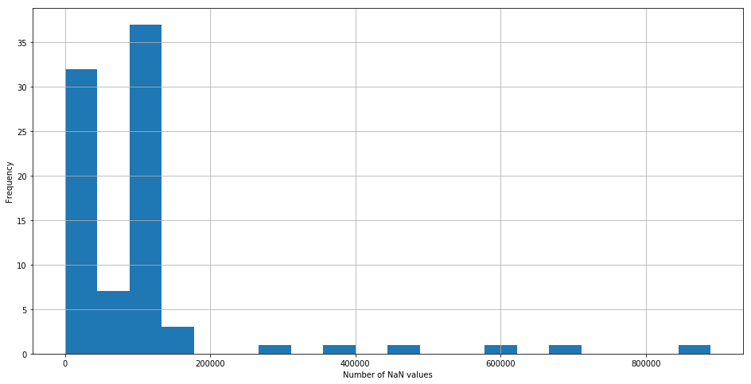

```python
# Perform an assessment of how much missing data there is in each column of the
# dataset.
plt.rcParams["figure.figsize"] = 16,8
plt.rcParams["axes.grid"] = True
plt.hist(x,bins=20)
plt.xlabel("Number of NaN values")
plt.ylabel("Frequency")
plt.show()
```

Most of the features have less than **200000** missing values.

Finding these columns

```python
azdias.isna().sum()[azdias.isna().sum() > 200000]
```

```
AGER_TYP        685843
GEBURTSJAHR     392318
TITEL_KZ        889061
ALTER_HH        310267
KK_KUNDENTYP    584612
KBA05_BAUMAX    476524
dtype: int64
```

```python
print("Outlier features: ")
outliers = azdias.isna().sum()[azdias.isna().sum() > 200000].index
for i in outliers:
    print(i)
```

```
Outlier features:
AGER_TYP
GEBURTSJAHR
TITEL_KZ
ALTER_HH
KK_KUNDENTYP
KBA05_BAUMAX
```

##### Creating a colormap to examine the missing values visually.

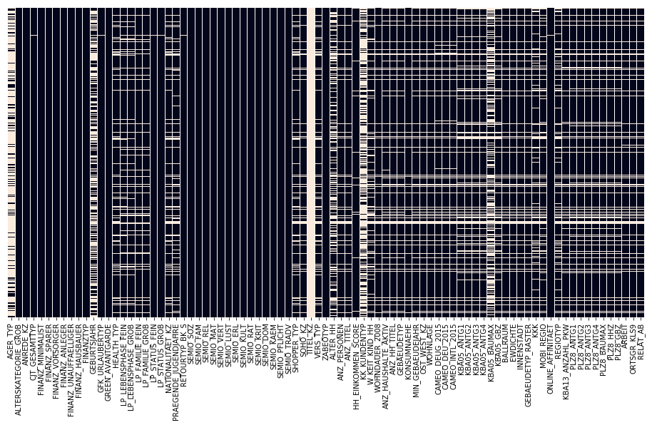

```python
# Investigate patterns in the amount of missing data in each column.
sns.heatmap(azdias.isna(),cbar=False,xticklabels=azdias.columns,yticklabels=False,)
```

The black part of the colormap is the values where there are no missing values. And the white part where the values are missing.

```python
# Remove the outlier columns from the dataset. (You'll perform other data
# engineering tasks such as re-encoding and imputation later.)
df = azdias.drop(outliers,axis=1)
```

#### Discussion 1.1.2: Assess Missing Data in Each Column

Observations regarding the missing values:

- Most of the columns have missing values, in these columns the number of the missing values are less than ~200000.
- There are 6 columns, where the number of the missing values are significantly more than in the other columns. (more than 200000)
  - `AGER_TYP`: Best-ager typology
  - `GEBURTSJAHR`: Year of birth
  - `TITEL_KZ`: Academic title flag
  - `ALTER_HH`: Birthdate of head of household
  - `KK_KUNDENTYP`: Consumer pattern over past 12 months
  - `KBA05_BAUMAX`: Most common building type within the microcell

These columns were removed from the dataframe. These patterns can be recognised in the colormap as well.

#### Step 1.1.3: Assess Missing Data in Each Row

Now, you'll perform a similar assessment for the rows of the dataset. How much data is missing in each row? As with the columns, you should see some groups of points that have a very different numbers of missing values. Divide the data into two subsets: one for data points that are above some threshold for missing values, and a second subset for points below that threshold.

In order to know what to do with the outlier rows, we should see if the distribution of data values on columns that are not missing data (or are missing very little data) are similar or different between the two groups. Select at least five of these columns and compare the distribution of values.

- You can use seaborn's [`countplot()`](https://seaborn.pydata.org/generated/seaborn.countplot.html) function to create a bar chart of code frequencies and matplotlib's [`subplot()`](https://matplotlib.org/api/_as_gen/matplotlib.pyplot.subplot.html) function to put bar charts for the two subplots side by side.
- To reduce repeated code, you might want to write a function that can perform this comparison, taking as one of its arguments a column to be compared.

Depending on what you observe in your comparison, this will have implications on how you approach your conclusions later in the analysis. If the distributions of non-missing features look similar between the data with many missing values and the data with few or no missing values, then we could argue that simply dropping those points from the analysis won't present a major issue. On the other hand, if the data with many missing values looks very different from the data with few or no missing values, then we should make a note on those data as special. We'll revisit these data later on. **Either way, you should continue your analysis for now using just the subset of the data with few or no missing values.**

```python
# How much data is missing in each row of the dataset?
missing_in_rows = df.isna().sum(axis=1)
missing_in_rows.head()
```

```
0    43
1     0
2     0
3     7
4     0
dtype: int64
```

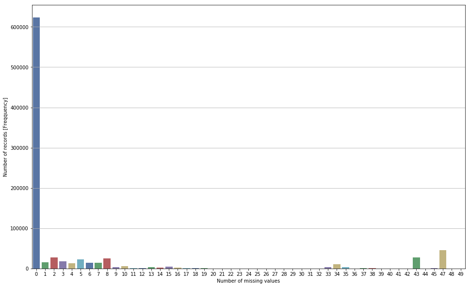

```python
plt.figure(figsize=(16,10))
sns.countplot(missing_in_rows,palette="deep")
plt.xlabel("Number of missing values")
plt.ylabel("Number of records [Freqquency]",)
plt.show()
```

```python
print("There are no missing values in {} rows.".format((missing_in_rows <= 20).sum()))
print("There are missing values in {} rows".format((missing_in_rows > 20).sum()))
```

[output not shown]

```python
# Write code to divide the data into two subsets based on the number of missing
# values in each row.
def divide_df(df):

    sub1 = df[df.isna().sum(axis=1) <= 20]
    sub2 = df[df.isna().sum(axis=1)> 20]

    return sub1,sub2
```

```python
sub1, sub2 = divide_df(df)
```

```python
# Compare the distribution of values for at least five columns where there are
# no or few missing values, between the two subsets.
```

Selecting the 5 columns where there are few missing values.

```python
columns_to_compare = missing.sort_values()[0:5].index
```

```python
def compare_hist(df1,df2,n=5,title1 = "DF1", title2="DF2"):

    plot_param_1 = 121
    plot_param_2 = 122

    for k,i in enumerate(columns_to_compare):

        plt.figure(figsize=(16,6))

        plt.subplot(plot_param_1)
        plt.title(title1)
        sns.countplot(df1[columns_to_compare[k]],palette="deep")

        plt.subplot(plot_param_2)
        plt.title(title2)
        sns.countplot(df2[columns_to_compare[k]],palette="deep")
```

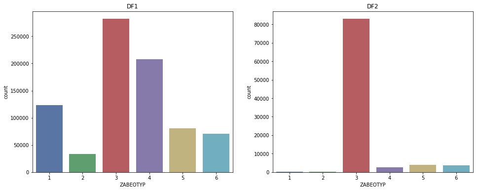

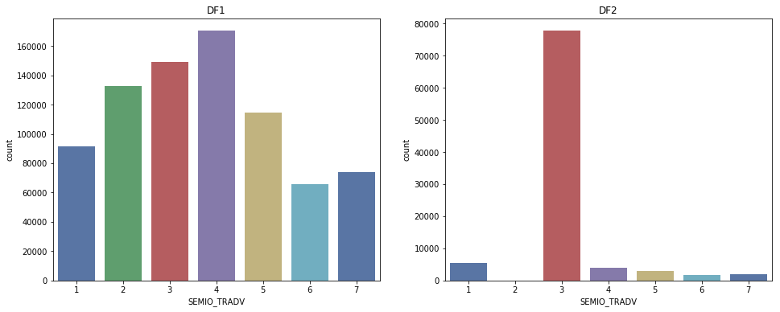

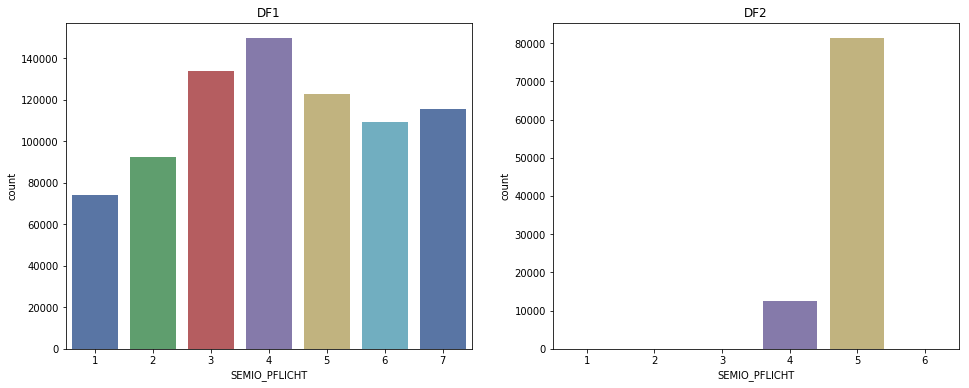

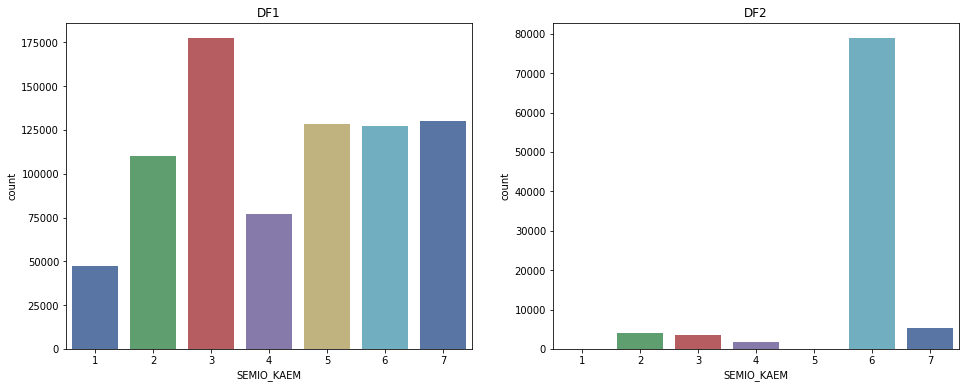

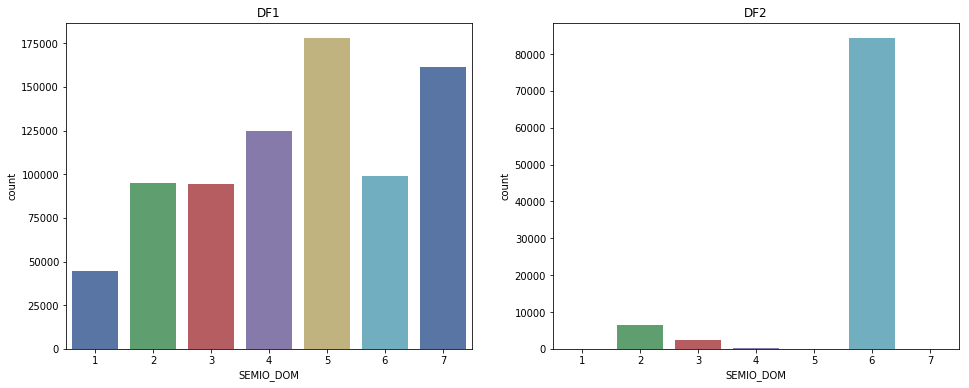

```python
compare_hist(sub1,sub2)
```

#### Discussion 1.1.3: Assess Missing Data in Each Row

In the previous section I made a colormap for checking the missing values in the whole dataframe. In the rows there are patterns in the data, in some section (where there are more missing values after each other) more missing values can be recognized.I checked the number of missing values in a countplot, where there is a trend, that the most of the rows have less than 20 missing values. According to these observations I separated the data in two subsets:

- subset 1: rows with less than **20** missing values
- subset 2: rows with more than **20** missing values

### Step 1.2: Select and Re-Encode Features

Checking for missing data isn't the only way in which you can prepare a dataset for analysis. Since the unsupervised learning techniques to be used will only work on data that is encoded numerically, you need to make a few encoding changes or additional assumptions to be able to make progress. In addition, while almost all of the values in the dataset are encoded using numbers, not all of them represent numeric values. Check the third column of the feature summary (`feat_info`) for a summary of types of measurement.

- For numeric and interval data, these features can be kept without changes.
- Most of the variables in the dataset are ordinal in nature. While ordinal values may technically be non-linear in spacing, make the simplifying assumption that the ordinal variables can be treated as being interval in nature (that is, kept without any changes).
- Special handling may be necessary for the remaining two variable types: categorical, and 'mixed'.

In the first two parts of this sub-step, you will perform an investigation of the categorical and mixed-type features and make a decision on each of them, whether you will keep, drop, or re-encode each. Then, in the last part, you will create a new data frame with only the selected and engineered columns.

Data wrangling is often the trickiest part of the data analysis process, and there's a lot of it to be done here. But stick with it: once you're done with this step, you'll be ready to get to the machine learning parts of the project!

One example for each category

```python
feat_info.groupby("type").first()["attribute"]
```

```
type
categorical                AGER_TYP
interval                   ALTER_HH
mixed           LP_LEBENSPHASE_FEIN
numeric                 GEBURTSJAHR
ordinal        ALTERSKATEGORIE_GROB
Name: attribute, dtype: object
```

```python
# How many features are there of each data type?
feat_info.type.value_counts()
```

```
ordinal        49
categorical    21
numeric         7
mixed           7
interval        1
Name: type, dtype: int64
```

```python
categories = feat_info.set_index("attribute")["type"].to_dict()
```

```python
df.dtypes.value_counts()
```

```
float64    51
int64      24
object      4
dtype: int64
```

Finding the categorical columns

```python
categorical_columns = list(feat_info[feat_info["type"] == "categorical"]["attribute"])
```

#### Step 1.2.1: Re-Encode Categorical Features

For categorical data, you would ordinarily need to encode the levels as dummy variables. Depending on the number of categories, perform one of the following:

- For binary (two-level) categoricals that take numeric values, you can keep them without needing to do anything.
- There is one binary variable that takes on non-numeric values. For this one, you need to re-encode the values as numbers or create a dummy variable.
- For multi-level categoricals (three or more values), you can choose to encode the values using multiple dummy variables (e.g. via [OneHotEncoder](http://scikit-learn.org/stable/modules/generated/sklearn.preprocessing.OneHotEncoder.html)), or (to keep things straightforward) just drop them from the analysis. As always, document your choices in the Discussion section.

Finding **binary** (two-level) categoricals

```python
binary = []
non_numeric_binary = []
for i in df.columns:
    if df[i].dropna().value_counts().count() == 2:
        if isinstance( df[i].dropna().iloc[0], str):
            non_numeric_binary.append(i)
        else:
            binary.append(i)
```

```python
non_numeric_binary
```

```
['OST_WEST_KZ']
```

##### Creating dummy variabels for the column where are the variabels strings

```python
dummies_non_num = pd.get_dummies(df["OST_WEST_KZ"])
dummies_non_num.head()
```

|  | O | W |
| --- | --- | --- |
| 0 | 0 | 0 |
| 1 | 0 | 1 |
| 2 | 0 | 1 |
| 3 | 0 | 1 |
| 4 | 0 | 1 |

Finding **multi-level** categoricals

```python
multi = []

for i in categorical_columns:
    try:
        if df[i].dropna().value_counts().count() > 2:
            multi.append(i)
    except:
        pass
```

**Binary** Categorical columns

```python
binary
```

```
['ANREDE_KZ', 'GREEN_AVANTGARDE', 'SOHO_KZ', 'VERS_TYP']
```

**Multi-level** categories

```python
multi
```

```
['CJT_GESAMTTYP',
 'FINANZTYP',
 'GFK_URLAUBERTYP',
 'LP_FAMILIE_FEIN',
 'LP_FAMILIE_GROB',
 'LP_STATUS_FEIN',
 'LP_STATUS_GROB',
 'NATIONALITAET_KZ',
 'SHOPPER_TYP',
 'ZABEOTYP',
 'GEBAEUDETYP',
 'CAMEO_DEUG_2015',
 'CAMEO_DEU_2015']
```

```python
for i in categorical_columns:
        if i not in (multi+binary):
            print(i)
```

```
AGER_TYP
TITEL_KZ
KK_KUNDENTYP
OST_WEST_KZ
```

All columns should be string to do the dummy variable step

```python
df[multi] = df[multi].astype(str)
```

```python
dummies_multi = pd.get_dummies(df[multi].dropna())
```

Creating a DataFrame with the dummy variables, and **dropping** the originals.

```python
new_df = pd.concat([df.drop(non_numeric_binary+multi,axis=1),dummies_non_num,dummies_multi],axis=1)
```

#### Discussion 1.2.1: Re-Encode Categorical Features

In this part of the project I did the following steps:

1. I checked the categories → there are **21** categorical features in the DataFrame
2. I created a list to work only with the categorical features
3. I created three list for the different type of data:
   - `binary`: list with the name of the features with binary numeric variables
   - `non_numeric_binary`: list with the name of the features with binary **non** numeric variables
   - `multi`: list with name of the features with multi-level variable
4. I created a new dataframe with dummy variables for the binary non numeric feature.
5. I created another dataframe with dummy variables for the multi-level features
6. Finally I created a new DataFrame from the two dummy variable DataFrame and from the original DataFrame, where I dropped the original features, which were used to create the dummy variables.

#### Step 1.2.2: Engineer Mixed-Type Features

There are a handful of features that are marked as "mixed" in the feature summary that require special treatment in order to be included in the analysis. There are two in particular that deserve attention; the handling of the rest are up to your own choices:

- "PRAEGENDE_JUGENDJAHRE" combines information on three dimensions: generation by decade, movement (mainstream vs. avantgarde), and nation (east vs. west). While there aren't enough levels to disentangle east from west, you should create two new variables to capture the other two dimensions: an interval-type variable for decade, and a binary variable for movement.
- "CAMEO_INTL_2015" combines information on two axes: wealth and life stage. Break up the two-digit codes by their 'tens'-place and 'ones'-place digits into two new ordinal variables (which, for the purposes of this project, is equivalent to just treating them as their raw numeric values).
- If you decide to keep or engineer new features around the other mixed-type features, make sure you note your steps in the Discussion section.

Be sure to check `Data_Dictionary.md` for the details needed to finish these tasks.

Listing out the mixed type features

```python
mixed = feat_info[feat_info["type"] == "mixed"]["attribute"]
mixed
```

```
15      LP_LEBENSPHASE_FEIN
16      LP_LEBENSPHASE_GROB
22    PRAEGENDE_JUGENDJAHRE
56                 WOHNLAGE
59          CAMEO_INTL_2015
64             KBA05_BAUMAX
79              PLZ8_BAUMAX
Name: attribute, dtype: object
```

```python
mixed_to_drop = []
for i in mixed:
    if i not in ["PRAEGENDE_JUGENDJAHRE","CAMEO_INTL_2015"]:
        mixed_to_drop.append(i)
```

```python
mixed_to_drop
```

```
['LP_LEBENSPHASE_FEIN',
 'LP_LEBENSPHASE_GROB',
 'WOHNLAGE',
 'KBA05_BAUMAX',
 'PLZ8_BAUMAX']
```

### 1.18. PRAEGENDE_JUGENDJAHRE

Dominating movement of person's youth (avantgarde vs. mainstream; east vs. west)

- -1: unknown
- 0: unknown
- 1: 40s - war years (Mainstream, E+W)
- 2: 40s - reconstruction years (Avantgarde, E+W)
- 3: 50s - economic miracle (Mainstream, E+W)
- 4: 50s - milk bar / Individualisation (Avantgarde, E+W)
- 5: 60s - economic miracle (Mainstream, E+W)
- 6: 60s - generation 68 / student protestors (Avantgarde, W)
- 7: 60s - opponents to the building of the Wall (Avantgarde, E)
- 8: 70s - family orientation (Mainstream, E+W)
- 9: 70s - peace movement (Avantgarde, E+W)
- 10: 80s - Generation Golf (Mainstream, W)
- 11: 80s - ecological awareness (Avantgarde, W)
- 12: 80s - FDJ / communist party youth organisation (Mainstream, E)
- 13: 80s - Swords into ploughshares (Avantgarde, E)
- 14: 90s - digital media kids (Mainstream, E+W)
- 15: 90s - ecological awareness (Avantgarde, E+W)

```python
# Investigate "PRAEGENDE_JUGENDJAHRE" and engineer two new variables.

def pj_movement(x):

    my_dict = {1: "Mainstream", 2:"Avantgarde", 3:"Mainstream", 4:"Avantgarde", 5:"Mainstream",
     6: "Avantgarde", 7:"Avantgarde" ,8:"Mainstream", 9:"Avantgarde", 10:"Mainstream",
     11:"Avantgarde", 12: "Mainstream",13:"Avantgarde", 14:"Mainstream", 15:"Avantgarde"}

    x = my_dict[x]
    if x == "Mainstream":
        x = 1
        return x
    else:
        x = 0
        return x

def pj_decade(x):

    my_dict = {1:1, 2:1, 3:2, 4:2, 5:3,
     6:3, 7:3, 8:4, 9:4, 10:5,
     11:5, 12:5, 13:5, 14:6, 15:6}

    x = my_dict[x]
    return x
```

```python
new_df["PRAEGENDE_JUGENDJAHRE_movement"] = new_df["PRAEGENDE_JUGENDJAHRE"].dropna().apply(pj_movement)
new_df["PRAEGENDE_JUGENDJAHRE_decade"] = new_df["PRAEGENDE_JUGENDJAHRE"].dropna().apply(pj_decade)
new_df.drop("PRAEGENDE_JUGENDJAHRE",axis = 1,inplace=True)
```

### 4.3. CAMEO_INTL_2015

German CAMEO: Wealth / Life Stage Typology, mapped to international code

- -1: unknown
- 11: Wealthy Households - Pre-Family Couples & Singles
- 12: Wealthy Households - Young Couples With Children
- 13: Wealthy Households - Families With School Age Children
- 14: Wealthy Households - Older Families & Mature Couples
- 15: Wealthy Households - Elders In Retirement
- 21: Prosperous Households - Pre-Family Couples & Singles
- 22: Prosperous Households - Young Couples With Children
- 23: Prosperous Households - Families With School Age Children
- 24: Prosperous Households - Older Families & Mature Couples
- 25: Prosperous Households - Elders In Retirement
- 31: Comfortable Households - Pre-Family Couples & Singles
- 32: Comfortable Households - Young Couples With Children
- 33: Comfortable Households - Families With School Age Children
- 34: Comfortable Households - Older Families & Mature Couples
- 35: Comfortable Households - Elders In Retirement
- 41: Less Affluent Households - Pre-Family Couples & Singles
- 42: Less Affluent Households - Young Couples With Children
- 43: Less Affluent Households - Families With School Age Children
- 44: Less Affluent Households - Older Families & Mature Couples
- 45: Less Affluent Households - Elders In Retirement
- 51: Poorer Households - Pre-Family Couples & Singles
- 52: Poorer Households - Young Couples With Children
- 53: Poorer Households - Families With School Age Children
- 54: Poorer Households - Older Families & Mature Couples
- 55: Poorer Households - Elders In Retirement
- XX: unknown

```python
# Investigate "CAMEO_INTL_2015" and engineer two new variables.
def ci_wealth(x):
    x = str(x)
    x=x[0]
    return int(x)

def ci_life_stage(x):
    x = str(x)
    x = x[0]
    return int(x)
```

```python
mixed_to_drop
```

[output not shown]

```python
new_df["CAMEO_INTL_2015_wealth"] = new_df["CAMEO_INTL_2015"].dropna().apply(ci_wealth)
new_df["CAMEO_INTL_2015_life_stage"] = new_df["CAMEO_INTL_2015"].dropna().apply(ci_life_stage)
new_df.drop("CAMEO_INTL_2015_life_stage",axis=1,inplace=True)
```

```python
new_df.drop(mixed_to_drop,axis=1,inplace=True)
```

#### Step 1.2.3: Complete Feature Selection

In order to finish this step up, you need to make sure that your data frame now only has the columns that you want to keep. To summarize, the dataframe should consist of the following:

- All numeric, interval, and ordinal type columns from the original dataset.
- Binary categorical features (all numerically-encoded).
- Engineered features from other multi-level categorical features and mixed features.

Make sure that for any new columns that you have engineered, that you've excluded the original columns from the final dataset. Otherwise, their values will interfere with the analysis later on the project. For example, you should not keep "PRAEGENDE_JUGENDJAHRE", since its values won't be useful for the algorithm: only the values derived from it in the engineered features you created should be retained. As a reminder, your data should only be from **the subset with few or no missing values**.

```python
# If there are other re-engineering tasks you need to perform, make sure you
# take care of them here. (Dealing with missing data will come in step 2.1.)
```

```python
# Do whatever you need to in order to ensure that the dataframe only contains
# the columns that should be passed to the algorithm functions.
```

### Step 1.3: Create a Cleaning Function

Even though you've finished cleaning up the general population demographics data, it's important to look ahead to the future and realize that you'll need to perform the same cleaning steps on the customer demographics data. In this substep, complete the function below to execute the main feature selection, encoding, and re-engineering steps you performed above. Then, when it comes to looking at the customer data in Step 3, you can just run this function on that DataFrame to get the trimmed dataset in a single step.

```python
def clean_data(df):
    """
    Perform feature trimming, re-encoding, and engineering for demographics
    data

    INPUT: Demographics DataFrame
    OUTPUT: Trimmed and cleaned demographics DataFrame
    """

    # Put in code here to execute all main cleaning steps:
    # convert missing value codes into NaNs, ...

    #function to parse the data
    def parser_list(x):
        x = x.replace("[","")
        x = x.replace("]","")
        x = x.split(',')

        new_x  = []
        for i in x:
            try:
                new_x.append(int(i))
            except:
                new_x.append(i)
        return new_x if len(new_x)>0 else np.NaN

    #applying the parser_list function
    feat_info["new_missing"] = feat_info["missing_or_unknown"].apply(parser_list)

    #changing the values to NA where needed
    for i in feat_info.dropna()["attribute"].unique():
        df[i] = df[i].where(~df[i].isin(feat_info["new_missing"].loc[feat_info.attribute == i].item()),np.NaN)

    # remove selected columns and rows, ...

    #creating a list with the name of the outlier columns
    #outliers = df.isna().sum()[df.isna().sum() > 200000].index

    #dropping the outlier columns
    df = df.drop(['AGER_TYP',"GEBURTSJAHR","TITEL_KZ","ALTER_HH","KK_KUNDENTYP","KBA05_BAUMAX"],axis=1)

    #in the customer dataset this feature has less categories than the azdias DataFrame
    df = df.drop(["GEBAEUDETYP"],axis = 1)

    # Write code to divide the data into two subsets based on the number of missing
    # values in each row.
    def divide_df(df):

        sub1 = df[df.isna().sum(axis=1) <=20]
        sub2 = df[df.isna().sum(axis=1)> 20]

        return sub1,sub2

    sub1,sub2 = divide_df(df)

    df = sub1

    # select, re-encode, and engineer column values.

    #list with the name of the categorical columns
    categorical_columns = list(feat_info[feat_info["type"] == "categorical"]["attribute"])

    #binary categorical features
    binary = []
    non_numeric_binary = []
    for i in df.columns:
        if df[i].dropna().value_counts().count() == 2:
            if isinstance( df[i].dropna().iloc[0], str):
                non_numeric_binary.append(i)
            else:
                binary.append(i)


    #creatung dummies from the non numeric binary feature
    dummies_non_num = pd.get_dummies(df[non_numeric_binary])

    #creating dummy variables from the multi-level columns
    multi = []
    for i in categorical_columns:
        try:
            if df[i].dropna().value_counts().count() > 2:
                multi.append(i)
        except:
            pass

    df[multi] = df[multi].dropna().astype(str)


    dummies_multi = pd.get_dummies(df[multi].dropna())

    #dropping the columns where dummy variables have been made, a concatonating all dataframe
    df = pd.concat([df.drop(non_numeric_binary+multi,axis=1),dummies_non_num,dummies_multi], axis = 1)

    #function to covert the mixed type data I/1
    def pj_movement(x):

        my_dict = {1: "Mainstream", 2:"Avantgarde", 3:"Mainstream", 4:"Avantgarde", 5:"Mainstream",
         6: "Avantgarde", 7:"Avantgarde" ,8:"Mainstream", 9:"Avantgarde", 10:"Mainstream",
         11:"Avantgarde", 12: "Mainstream",13:"Avantgarde", 14:"Mainstream", 15:"Avantgarde"}

        x = my_dict[x]
        if x == "Mainstream":
            x = 1
            return x
        else:
            x = 0
            return x
    #function to covert the mixed type data I/2
    def pj_decade(x):

        my_dict = {1:1, 2:1, 3:2, 4:2, 5:3,
         6:3, 7:3, 8:4, 9:4, 10:5,
         11:5, 12:5, 13:5, 14:6, 15:6}

        x = my_dict[x]
        return x

    #applying the functions
    df["PRAEGENDE_JUGENDJAHRE_movement"] = df["PRAEGENDE_JUGENDJAHRE"].dropna().apply(pj_movement)
    df["PRAEGENDE_JUGENDJAHRE_decade"] = df["PRAEGENDE_JUGENDJAHRE"].dropna().apply(pj_decade)
    df = df.drop("PRAEGENDE_JUGENDJAHRE",axis = 1)


    #function to covert the mixed type data II/1
    def ci_wealth(x):
        x = str(x)
        x=x[0]
        return int(x)

    #function to covert the mixed type data II/2
    def ci_life_stage(x):
        x = str(x)
        x = x[0]
        return int(x)

    #applying the functions
    df["CAMEO_INTL_2015_wealth"] = df["CAMEO_INTL_2015"].dropna().apply(ci_wealth)
    df["CAMEO_INTL_2015_life_stage"] = df["CAMEO_INTL_2015"].dropna().apply(ci_life_stage)
    df = df.drop("CAMEO_INTL_2015",axis = 1)

    #dropping the other mixed features
    mixed_to_drop = ['LP_LEBENSPHASE_FEIN','LP_LEBENSPHASE_GROB','WOHNLAGE','PLZ8_BAUMAX']

    df.drop(mixed_to_drop,axis = 1, inplace=True)

    # Return the cleaned dataframe.
    return df
```

```python
df = clean_data(azdias)
```

```python
df.shape
```

```
(797426, 186)
```

## Step 2: Feature Transformation

### Step 2.1: Apply Feature Scaling

Before we apply dimensionality reduction techniques to the data, we need to perform feature scaling so that the principal component vectors are not influenced by the natural differences in scale for features. Starting from this part of the project, you'll want to keep an eye on the [API reference page for sklearn](http://scikit-learn.org/stable/modules/classes.html) to help you navigate to all of the classes and functions that you'll need. In this substep, you'll need to check the following:

- sklearn requires that data not have missing values in order for its estimators to work properly. So, before applying the scaler to your data, make sure that you've cleaned the DataFrame of the remaining missing values. This can be as simple as just removing all data points with missing data, or applying an [Imputer](http://scikit-learn.org/stable/modules/generated/sklearn.preprocessing.Imputer.html) to replace all missing values. You might also try a more complicated procedure where you temporarily remove missing values in order to compute the scaling parameters before re-introducing those missing values and applying imputation. Think about how much missing data you have and what possible effects each approach might have on your analysis, and justify your decision in the discussion section below.
- For the actual scaling function, a [StandardScaler](http://scikit-learn.org/stable/modules/generated/sklearn.preprocessing.StandardScaler.html) instance is suggested, scaling each feature to mean 0 and standard deviation 1.
- For these classes, you can make use of the `.fit_transform()` method to both fit a procedure to the data as well as apply the transformation to the data at the same time. Don't forget to keep the fit sklearn objects handy, since you'll be applying them to the customer demographics data towards the end of the project.

```python
# If you've not yet cleaned the dataset of all NaN values, then investigate and
# do that now.
#Applying  Imputer
imp = Imputer(strategy='most_frequent')
new_df = imp.fit_transform(df)
```

```python
# Apply feature scaling to the general population demographics data.
scaler = StandardScaler()
new_df = pd.DataFrame(columns=df.columns,data=scaler.fit_transform(new_df))
```

### Discussion 2.1: Apply Feature Scaling

I decided to use the Imputer to completing missing values, because the DataFrame have numerous missing values. I use the most_frequent option of the imputer to use the most frequent value of the feature, and so the influence of the operation is not high. After that I have I dataframe which I can scale. For scaling the data I use the StandardScaler.

### Step 2.2: Perform Dimensionality Reduction

On your scaled data, you are now ready to apply dimensionality reduction techniques.

- Use sklearn's [PCA](http://scikit-learn.org/stable/modules/generated/sklearn.decomposition.PCA.html) class to apply principal component analysis on the data, thus finding the vectors of maximal variance in the data. To start, you should not set any parameters (so all components are computed) or set a number of components that is at least half the number of features (so there's enough features to see the general trend in variability).
- Check out the ratio of variance explained by each principal component as well as the cumulative variance explained. Try plotting the cumulative or sequential values using matplotlib's [`plot()`](https://matplotlib.org/api/_as_gen/matplotlib.pyplot.plot.html) function. Based on what you find, select a value for the number of transformed features you'll retain for the clustering part of the project.
- Once you've made a choice for the number of components to keep, make sure you re-fit a PCA instance to perform the decided-on transformation.

```python
# Apply PCA to the data.
```

```python
pca = PCA()
X_pca = pca.fit_transform(new_df)
```

```python
# Investigate the variance accounted for by each principal component.
def plot_var(pca):

    plt.figure(figsize=(16,10))

    n_comp = len(pca.explained_variance_ratio_)
    ncom = np.arange(n_comp)
    variance = pca.explained_variance_ratio_

    cum = np.cumsum(variance)

    #Check out the ratio of variance explained by each principal component as well as the cumulative variance explained.
    plt.bar(ncom, variance)
    plt.plot(ncom, cum)


    #plt.plot(ncom, cum/variance.sum())

    plt.xlabel("Principal Component")
    plt.ylabel("Variance Explained (%)")
    plt.title('Explained Variance Per Principal Component')
```

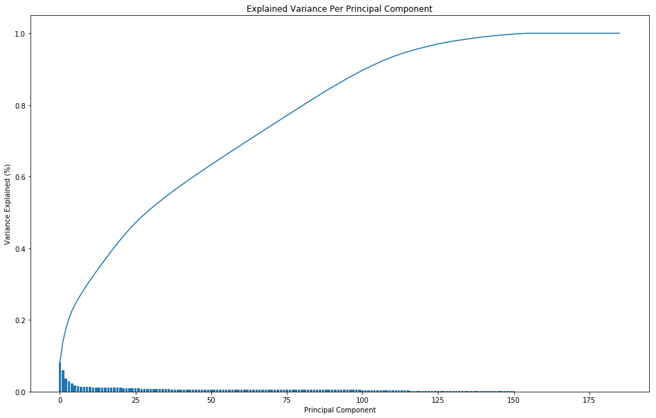

```python
plot_var(pca)
```

```python
# Re-apply PCA to the data while selecting for number of components to retain.
def my_pca(df,n):
    """
    df: DataFrame wiche has been already scaled.
    n: number of components

    """

    pca = PCA(n_components = n)
    X_pca = pca.fit_transform(df)

    return pca, X_pca
```

```python
pca, X_pca = my_pca(new_df,0.9)
```

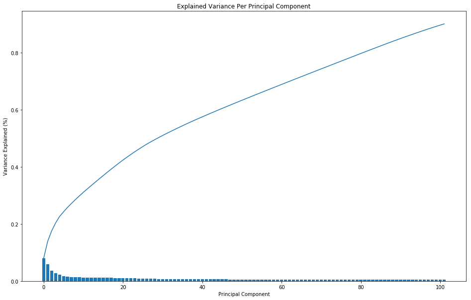

```python
plot_var(pca)
```

### Discussion 2.2: Perform Dimensionality Reduction

The variance for each principal component have been plotted with the basic PCA parameters. Next to the variance explained for each component I plotted the cummulativsum to examine the complete variablity with n components. I choosed a parameter for the pca where the variance is more than 90% and so the data is well described, and the number of component is significantly less, than the number of features.

### Step 2.3: Interpret Principal Components

Now that we have our transformed principal components, it's a nice idea to check out the weight of each variable on the first few components to see if they can be interpreted in some fashion.

As a reminder, each principal component is a unit vector that points in the direction of highest variance (after accounting for the variance captured by earlier principal components). The further a weight is from zero, the more the principal component is in the direction of the corresponding feature. If two features have large weights of the same sign (both positive or both negative), then increases in one tend expect to be associated with increases in the other. To contrast, features with different signs can be expected to show a negative correlation: increases in one variable should result in a decrease in the other.

- To investigate the features, you should map each weight to their corresponding feature name, then sort the features according to weight. The most interesting features for each principal component, then, will be those at the beginning and end of the sorted list. Use the data dictionary document to help you understand these most prominent features, their relationships, and what a positive or negative value on the principal component might indicate.
- You should investigate and interpret feature associations from the first three principal components in this substep. To help facilitate this, you should write a function that you can call at any time to print the sorted list of feature weights, for the *i*-th principal component. This might come in handy in the next step of the project, when you interpret the tendencies of the discovered clusters.

```python
def weights(pca, c):

    w_df = pd.DataFrame({'weight': (pca.components_[c])}, index=new_df.columns)
    print("Component: ", c)
    print(w_df.sort_values("weight").head(2))
    print("\n")
    print(w_df.sort_values("weight").tail(2))

    return w_df
```

```python
# Map weights for the first principal component to corresponding feature names
# and then print the linked values, sorted by weight.
# HINT: Try defining a function here or in a new cell that you can reuse in the
# other cells.

# Map weights for the second principal component to corresponding feature names
# and then print the linked values, sorted by weight.

# Map weights for the third principal component to corresponding feature names
# and then print the linked values, sorted by weight.


for i in range(3):
    print(f"Mapping for the {i+1}. component")
    w_df = weights(pca,i)
    print("\n")
    print("-"*40)
```

```
Mapping for the 1. component
Component:  0
                     weight
MOBI_REGIO        -0.189983
FINANZ_MINIMALIST -0.189846


                              weight
CAMEO_INTL_2015_life_stage  0.193102
CAMEO_INTL_2015_wealth      0.193102


----------------------------------------
Mapping for the 2. component
Component:  1
                                weight
PRAEGENDE_JUGENDJAHRE_decade -0.231577
FINANZ_SPARER                -0.228471


                        weight
FINANZ_VORSORGER      0.220853
ALTERSKATEGORIE_GROB  0.238919


----------------------------------------
Mapping for the 3. component
Component:  2
              weight
ANREDE_KZ  -0.347428
SEMIO_KAEM -0.317733


              weight
SEMIO_FAM   0.260885
SEMIO_VERT  0.320856


----------------------------------------
```

```python
def pca_weight_print(i):
    print(f"Mapping for the {i+1}. component")
    w_df = weights(pca,i)
    print("\n")
    print("-"*40)
```

```python
pca_weight_print(3)
```

```
Mapping for the 4. component
Component:  3
                                  weight
PRAEGENDE_JUGENDJAHRE_movement -0.284306
LP_STATUS_GROB_4.0             -0.187363


                       weight
LP_STATUS_FEIN_10.0  0.239261
GREEN_AVANTGARDE     0.284306


----------------------------------------
```

### Discussion 2.3: Interpret Principal Components

The principal components have a value for each feature in the original data frame. Each value tells us how much influance have the feature in the principal component. We can interpret for example the first component, that the CAMEO_INTL_2015_wealth, and CAMEO_INTL_2015_life_stage have the most influence.

The Features with the high influance:

**Component 1:**

- MOBI_REGIO
- CAMEO_INTL_2015_wealth
- CAMEO_INTL_2015_life_stage

**Component 2:**

- PRAEGENDE_JUGENDJAHRE_decade
- ALTERSKATEGORIE_GROB

**Component 3:**

- ANREDE_KZ
- SEMIO_VERT

## Step 3: Clustering

### Step 3.1: Apply Clustering to General Population

You've assessed and cleaned the demographics data, then scaled and transformed them. Now, it's time to see how the data clusters in the principal components space. In this substep, you will apply k-means clustering to the dataset and use the average within-cluster distances from each point to their assigned cluster's centroid to decide on a number of clusters to keep.

- Use sklearn's KMeans class to perform k-means clustering on the PCA-transformed data.
- Then, compute the average difference from each point to its assigned cluster's center. **Hint**: The KMeans object's `.score()` method might be useful here, but note that in sklearn, scores tend to be defined so that larger is better. Try applying it to a small, toy dataset, or use an internet search to help your understanding.
- Perform the above two steps for a number of different cluster counts. You can then see how the average distance decreases with an increasing number of clusters. However, each additional cluster provides a smaller net benefit. Use this fact to select a final number of clusters in which to group the data. **Warning**: because of the large size of the dataset, it can take a long time for the algorithm to resolve. The more clusters to fit, the longer the algorithm will take. You should test for cluster counts through at least 10 clusters to get the full picture, but you shouldn't need to test for a number of clusters above about 30.
- Once you've selected a final number of clusters to use, re-fit a KMeans instance to perform the clustering operation. Make sure that you also obtain the cluster assignments for the general demographics data, since you'll be using them in the final Step 3.3.

```python
# Over a number of different cluster counts...

# run k-means clustering on the data and...
# compute the average within-cluster distances.
def kmean(df,n):
    model = KMeans(n_clusters=n)
    model = model.fit(df)
    pred = model.fit_predict(df)
    score = np.abs(model.score(df))

    return score
```

```python
scores = []

for i in range(10,30,2):
    start = time.time()
    score = kmean(X_pca,i)
    scores.append(score)
    end = time.time()
    print("Number of clusters: ",i)
    print("Length of the calculation: ", end-start," s")
```

```
Number of clusters:  10
Length of the calculation:  448.0179286003113  s
Number of clusters:  12
Length of the calculation:  485.6424434185028  s
Number of clusters:  14
Length of the calculation:  511.00353264808655  s
Number of clusters:  16
Length of the calculation:  566.8838174343109  s
Number of clusters:  18
Length of the calculation:  692.7022361755371  s
Number of clusters:  20
Length of the calculation:  684.720155954361  s
Number of clusters:  22
Length of the calculation:  849.6282482147217  s
Number of clusters:  24
Length of the calculation:  999.5177311897278  s
Number of clusters:  26
Length of the calculation:  861.6187491416931  s
Number of clusters:  28
Length of the calculation:  922.5589609146118  s
```

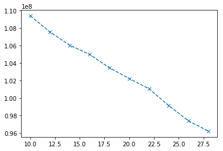

```python
# Investigate the change in within-cluster distance across number of clusters.
# HINT: Use matplotlib's plot function to visualize this relationship.
plt.plot(range(10,30,2),scores,marker = "x", ls = "--")
```

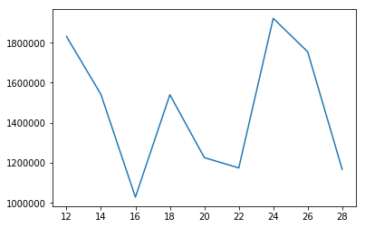

```python
eval_df = pd.DataFrame({"scores" : scores},index=range(10,30,2))
eval_df["scores+1"] = eval_df.scores.shift(1)
eval_df["delta"] = eval_df["scores+1"] - eval_df["scores"]
eval_df['delta'].plot()
```

```python
scores
```

```
[109399559.83984973,
 107568566.47598846,
 106027040.09684941,
 104998588.02856261,
 103458449.01097259,
 102232398.56999177,
 101057872.87548421,
 99136114.156563744,
 97381801.272644073,
 96214306.624039739]
```

```python
# Re-fit the k-means model with the selected number of clusters and obtain
# cluster predictions for the general population demographics data.
def kmean(df,n):
    model = KMeans(n_clusters=n)
    model = model.fit(df)
    pred = model.fit_predict(df)
    score = np.abs(model.score(df))

    return pred,score, model

pred, score, model= kmean(X_pca,14)
```

### Discussion 3.1: Apply Clustering to General Population

Because each additional cluster provides a smaller net benefit, I choosed a number of cluster where this number is small, but the average distance is already smaller, than the distances with smaller cluster numbers.

### Step 3.2: Apply All Steps to the Customer Data

Now that you have clusters and cluster centers for the general population, it's time to see how the customer data maps on to those clusters. Take care to not confuse this for re-fitting all of the models to the customer data. Instead, you're going to use the fits from the general population to clean, transform, and cluster the customer data. In the last step of the project, you will interpret how the general population fits apply to the customer data.

- Don't forget when loading in the customers data, that it is semicolon (`;`) delimited.
- Apply the same feature wrangling, selection, and engineering steps to the customer demographics using the `clean_data()` function you created earlier. (You can assume that the customer demographics data has similar meaning behind missing data patterns as the general demographics data.)
- Use the sklearn objects from the general demographics data, and apply their transformations to the customers data. That is, you should not be using a `.fit()` or `.fit_transform()` method to re-fit the old objects, nor should you be creating new sklearn objects! Carry the data through the feature scaling, PCA, and clustering steps, obtaining cluster assignments for all of the data in the customer demographics data.

```python
# Load in the customer demographics data.
customers = pd.read_csv("Udacity_CUSTOMERS_Subset.csv", sep=";")
```

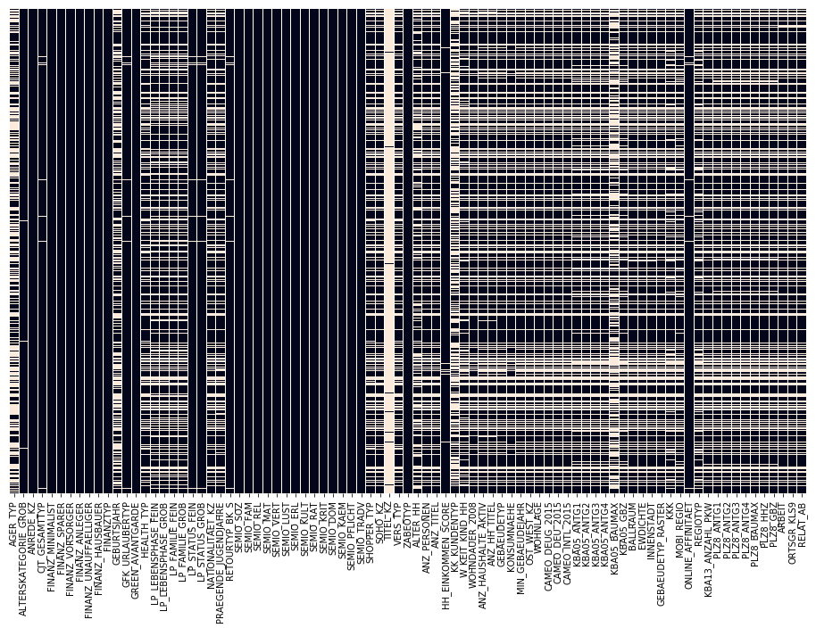

```python
plt.figure(figsize=(16,10))
sns.heatmap(customers.isna(),cbar=False,xticklabels=customers.columns,yticklabels=False,)
```

```python
customers.describe()
```

|  | AGER_TYP | ALTERSKATEGORIE_GROB | ANREDE_KZ | CJT_GESAMTTYP | FINANZ_MINIMALIST | FINANZ_SPARER | FINANZ_VORSORGER | FINANZ_ANLEGER | FINANZ_UNAUFFAELLIGER | FINANZ_HAUSBAUER | ... | PLZ8_ANTG1 | PLZ8_ANTG2 | PLZ8_ANTG3 | PLZ8_ANTG4 | PLZ8_BAUMAX | PLZ8_HHZ | PLZ8_GBZ | ARBEIT | ORTSGR_KLS9 | RELAT_AB |
| --- | --- | --- | --- | --- | --- | --- | --- | --- | --- | --- | --- | --- | --- | --- | --- | --- | --- | --- | --- | --- | --- |
| count | 191652.000000 | 191652.000000 | 191652.000000 | 188439.000000 | 191652.000000 | 191652.000000 | 191652.000000 | 191652.000000 | 191652.000000 | 191652.000000 | ... | 138888.000000 | 138888.000000 | 138888.000000 | 138888.000000 | 138888.000000 | 138888.000000 | 138888.000000 | 141176.000000 | 141176.000000 | 141176.000000 |
| mean | 0.344359 | 3.060907 | 1.376432 | 3.677928 | 3.963773 | 2.057051 | 4.183317 | 2.439808 | 2.646176 | 2.781176 | ... | 2.537404 | 2.731510 | 1.388817 | 0.539939 | 1.556607 | 3.634893 | 3.622192 | 2.824850 | 5.119517 | 2.898510 |
| std | 1.391672 | 1.086254 | 0.484492 | 1.813975 | 1.036230 | 1.319422 | 0.995365 | 1.697932 | 1.586506 | 1.147353 | ... | 0.904927 | 0.840922 | 0.885038 | 0.637048 | 1.185736 | 0.933660 | 1.008472 | 1.012415 | 2.159184 | 1.422683 |
| min | -1.000000 | 1.000000 | 1.000000 | 1.000000 | 1.000000 | 1.000000 | 1.000000 | 1.000000 | 1.000000 | 1.000000 | ... | 0.000000 | 0.000000 | 0.000000 | 0.000000 | 1.000000 | 1.000000 | 1.000000 | 1.000000 | 1.000000 | 1.000000 |
| 25% | -1.000000 | 3.000000 | 1.000000 | 2.000000 | 3.000000 | 1.000000 | 3.000000 | 1.000000 | 1.000000 | 2.000000 | ... | 2.000000 | 2.000000 | 1.000000 | 0.000000 | 1.000000 | 3.000000 | 3.000000 | 2.000000 | 4.000000 | 2.000000 |
| 50% | 0.000000 | 3.000000 | 1.000000 | 4.000000 | 4.000000 | 1.000000 | 5.000000 | 2.000000 | 2.000000 | 3.000000 | ... | 3.000000 | 3.000000 | 1.000000 | 0.000000 | 1.000000 | 3.000000 | 4.000000 | 3.000000 | 5.000000 | 3.000000 |
| 75% | 2.000000 | 4.000000 | 2.000000 | 6.000000 | 5.000000 | 4.000000 | 5.000000 | 5.000000 | 5.000000 | 3.000000 | ... | 3.000000 | 3.000000 | 2.000000 | 1.000000 | 1.000000 | 4.000000 | 4.000000 | 4.000000 | 7.000000 | 4.000000 |
| max | 3.000000 | 9.000000 | 2.000000 | 6.000000 | 5.000000 | 5.000000 | 5.000000 | 5.000000 | 5.000000 | 5.000000 | ... | 4.000000 | 4.000000 | 3.000000 | 2.000000 | 5.000000 | 5.000000 | 5.000000 | 9.000000 | 9.000000 | 9.000000 |

8 rows × 81 columns

```python
# Apply preprocessing, feature transformation, and clustering from the general
# demographics onto the customer data, obtaining cluster predictions for the
# customer demographics data.
customers_df = clean_data(customers)
customers_df.describe()
```

|  | ALTERSKATEGORIE_GROB | ANREDE_KZ | FINANZ_MINIMALIST | FINANZ_SPARER | FINANZ_VORSORGER | FINANZ_ANLEGER | FINANZ_UNAUFFAELLIGER | FINANZ_HAUSBAUER | GREEN_AVANTGARDE | HEALTH_TYP | ... | CAMEO_DEU_2015_8D | CAMEO_DEU_2015_9A | CAMEO_DEU_2015_9B | CAMEO_DEU_2015_9C | CAMEO_DEU_2015_9D | CAMEO_DEU_2015_9E | PRAEGENDE_JUGENDJAHRE_movement | PRAEGENDE_JUGENDJAHRE_decade | CAMEO_INTL_2015_wealth | CAMEO_INTL_2015_life_stage |
| --- | --- | --- | --- | --- | --- | --- | --- | --- | --- | --- | --- | --- | --- | --- | --- | --- | --- | --- | --- | --- | --- |
| count | 141407.000000 | 141640.000000 | 141640.000000 | 141640.000000 | 141640.000000 | 141640.000000 | 141640.000000 | 141640.000000 | 141640.000000 | 139321.000000 | ... | 129784.000000 | 129784.000000 | 129784.000000 | 129784.000000 | 129784.000000 | 129784.000000 | 140357.000000 | 140357.000000 | 141038.000000 | 141038.000000 |
| mean | 3.487267 | 1.330669 | 4.263972 | 1.431213 | 4.563181 | 1.602062 | 1.865229 | 2.728587 | 0.496752 | 1.962375 | ... | 0.015141 | 0.007243 | 0.006264 | 0.006580 | 0.012975 | 0.009631 | 0.498707 | 2.887993 | 2.598619 | 2.598619 |
| std | 0.729862 | 0.470456 | 1.017852 | 0.834118 | 0.846222 | 1.002298 | 0.978148 | 1.316678 | 0.499991 | 0.772782 | ... | 0.122112 | 0.084796 | 0.078899 | 0.080851 | 0.113169 | 0.097666 | 0.500000 | 1.346648 | 1.404832 | 1.404832 |
| min | 1.000000 | 1.000000 | 1.000000 | 1.000000 | 1.000000 | 1.000000 | 1.000000 | 1.000000 | 0.000000 | 1.000000 | ... | 0.000000 | 0.000000 | 0.000000 | 0.000000 | 0.000000 | 0.000000 | 0.000000 | 1.000000 | 1.000000 | 1.000000 |
| 25% | 3.000000 | 1.000000 | 4.000000 | 1.000000 | 4.000000 | 1.000000 | 1.000000 | 2.000000 | 0.000000 | 1.000000 | ... | 0.000000 | 0.000000 | 0.000000 | 0.000000 | 0.000000 | 0.000000 | 0.000000 | 2.000000 | 1.000000 | 1.000000 |
| 50% | 4.000000 | 1.000000 | 5.000000 | 1.000000 | 5.000000 | 1.000000 | 2.000000 | 2.000000 | 0.000000 | 2.000000 | ... | 0.000000 | 0.000000 | 0.000000 | 0.000000 | 0.000000 | 0.000000 | 0.000000 | 3.000000 | 2.000000 | 2.000000 |
| 75% | 4.000000 | 2.000000 | 5.000000 | 2.000000 | 5.000000 | 2.000000 | 2.000000 | 4.000000 | 1.000000 | 3.000000 | ... | 0.000000 | 0.000000 | 0.000000 | 0.000000 | 0.000000 | 0.000000 | 1.000000 | 4.000000 | 4.000000 | 4.000000 |
| max | 4.000000 | 2.000000 | 5.000000 | 5.000000 | 5.000000 | 5.000000 | 5.000000 | 5.000000 | 1.000000 | 3.000000 | ... | 1.000000 | 1.000000 | 1.000000 | 1.000000 | 1.000000 | 1.000000 | 1.000000 | 6.000000 | 5.000000 | 5.000000 |

8 rows × 186 columns

Checking the shape sof the two dataframes

```python
df.shape
```

```
(797426, 186)
```

```python
customers_df.shape
```

```
(141640, 186)
```

##### Transforming the customer data

Creating a cluster for the records where the missing value more than 20 (as in the popoulation data). This going to be another cluster in the compersion.

```python
sub_2_customer = customers[customers.isna().sum(axis=1)> 20]
```

Transforming the customer data, for clusteing wthe the population imputer and scaler and pca.

```python
scaled_customer = scaler.transform(imp.transform(customers_df))
```

```python
X_pca_customer = pca.transform(scaled_customer)
```

Clusering the data

```python
pred_customer = model.predict(X_pca_customer)
```

### Step 3.3: Compare Customer Data to Demographics Data

At this point, you have clustered data based on demographics of the general population of Germany, and seen how the customer data for a mail-order sales company maps onto those demographic clusters. In this final substep, you will compare the two cluster distributions to see where the strongest customer base for the company is.

Consider the proportion of persons in each cluster for the general population, and the proportions for the customers. If we think the company's customer base to be universal, then the cluster assignment proportions should be fairly similar between the two. If there are only particular segments of the population that are interested in the company's products, then we should see a mismatch from one to the other. If there is a higher proportion of persons in a cluster for the customer data compared to the general population (e.g. 5% of persons are assigned to a cluster for the general population, but 15% of the customer data is closest to that cluster's centroid) then that suggests the people in that cluster to be a target audience for the company. On the other hand, the proportion of the data in a cluster being larger in the general population than the customer data (e.g. only 2% of customers closest to a population centroid that captures 6% of the data) suggests that group of persons to be outside of the target demographics.

Take a look at the following points in this step:

- Compute the proportion of data points in each cluster for the general population and the customer data. Visualizations will be useful here: both for the individual dataset proportions, but also to visualize the ratios in cluster representation between groups. Seaborn's [`countplot()`](https://seaborn.pydata.org/generated/seaborn.countplot.html) or [`barplot()`](https://seaborn.pydata.org/generated/seaborn.barplot.html) function could be handy.
  - Recall the analysis you performed in step 1.1.3 of the project, where you separated out certain data points from the dataset if they had more than a specified threshold of missing values. If you found that this group was qualitatively different from the main bulk of the data, you should treat this as an additional data cluster in this analysis. Make sure that you account for the number of data points in this subset, for both the general population and customer datasets, when making your computations!
- Which cluster or clusters are overrepresented in the customer dataset compared to the general population? Select at least one such cluster and infer what kind of people might be represented by that cluster. Use the principal component interpretations from step 2.3 or look at additional components to help you make this inference. Alternatively, you can use the `.inverse_transform()` method of the PCA and StandardScaler objects to transform centroids back to the original data space and interpret the retrieved values directly.
- Perform a similar investigation for the underrepresented clusters. Which cluster or clusters are underrepresented in the customer dataset compared to the general population, and what kinds of people are typified by these clusters?

Adding the rows with a lot of missing values from 1.1.3. The Cluster 14 will be the cluster of the records where the number of missing values are high.

```python
new_pred = np.append(pred,[14 for x in range(len(sub2))])
new_pred_customer = np.append(pred_customer,[14 for x in range(len(sub_2_customer))])
```

```python
compare_df = pd.DataFrame({"population": new_pred})
compare_df = pd.concat([compare_df,pd.Series(new_pred_customer)],axis = 1)
compare_df.columns = ["population","customer"]
compare_df["population_counter"] = 1
compare_df["customer_counter"] = 1
```

```python
population_dist = compare_df.groupby("population").agg({"population_counter": "sum"})
population_dist["population_dist"] = population_dist["population_counter"]/population_dist["population_counter"].sum()
population_dist
```

| population | population_counter | population_dist |
| --- | --- | --- |
| 0 | 78095 | 0.087627 |
| 1 | 73747 | 0.082748 |
| 2 | 92325 | 0.103594 |
| 3 | 46161 | 0.051795 |
| 4 | 32266 | 0.036204 |
| 5 | 106098 | 0.119048 |
| 6 | 61570 | 0.069085 |
| 7 | 54539 | 0.061196 |
| 8 | 9904 | 0.011113 |
| 9 | 46030 | 0.051648 |
| 10 | 29762 | 0.033395 |
| 11 | 71851 | 0.080621 |
| 12 | 91063 | 0.102178 |
| 13 | 4015 | 0.004505 |
| 14 | 93795 | 0.105243 |

```python
customer_dist = compare_df.groupby("customer").agg({"customer_counter": "sum"})
customer_dist["customer_dist"] = customer_dist["customer_counter"]/customer_dist["customer_counter"].sum()
customer_dist
```

| customer | customer_counter | customer_dist |
| --- | --- | --- |
| 0.0 | 2062 | 0.010733 |
| 1.0 | 9753 | 0.050767 |
| 2.0 | 49382 | 0.257045 |
| 3.0 | 4962 | 0.025828 |
| 4.0 | 14078 | 0.073279 |
| 5.0 | 28810 | 0.149963 |
| 6.0 | 871 | 0.004534 |
| 7.0 | 2788 | 0.014512 |
| 8.0 | 1789 | 0.009312 |
| 9.0 | 11782 | 0.061328 |
| 10.0 | 2864 | 0.014908 |
| 11.0 | 9126 | 0.047503 |
| 12.0 | 1298 | 0.006756 |
| 13.0 | 2075 | 0.010801 |
| 14.0 | 50474 | 0.262729 |

```python
def plot_compersion(df1,df2):
    plt.figure(figsize=(16,10))
    labels = range(0,15)
    population_dist = df1["population_dist"]
    customer_dist = df2["customer_dist"]

    x = np.arange(len(labels))  # the label locations

    width = 0.30  # the width of the bars

    plt.bar(x - width/2, population_dist*100, width, label='Population',alpha=0.8)
    plt.bar(x + width/2, customer_dist*100, width, label='Custmoer',alpha=0.8)

    for i in range(15):
        plt.annotate('{:.1f}%'.format(population_dist[i]*100),
                    xy=(i, population_dist[i]*100-1), xytext=(i, population_dist[i]*100-1), textcoords="offset points", ha='center')
        plt.annotate('{:.1f}%'.format(customer_dist[i]*100),
                xy=(i, customer_dist[i]*100-1), xytext=(i, customer_dist[i]*100-1), textcoords="offset points", ha='center')


    plt.title("Compare Cluster Distribution")
    plt.xlabel('Cluster')
    plt.ylabel("Frequency")
    plt.grid()
    plt.legend()
```

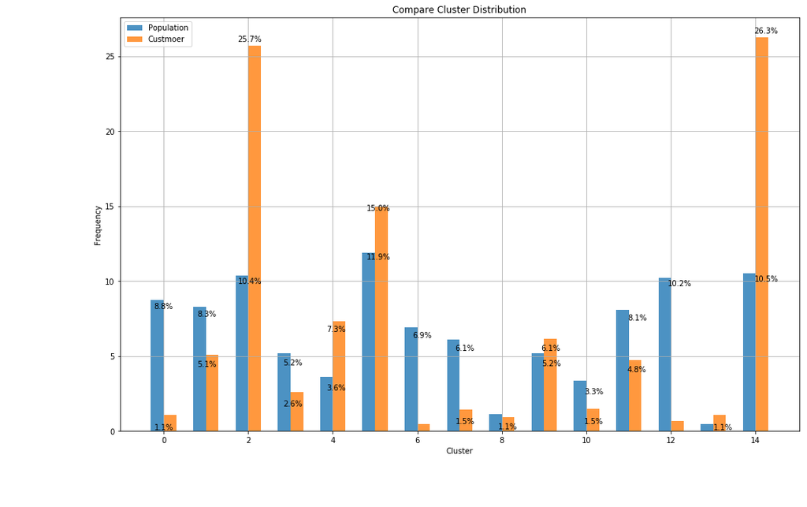

```python
plot_compersion(population_dist,customer_dist)
```

```python
result_df = pd.DataFrame(data=scaler.inverse_transform(pca.inverse_transform(model.cluster_centers_)),columns=customers_df.columns)
```

```python
result_df
```

|  | ALTERSKATEGORIE_GROB | ANREDE_KZ | FINANZ_MINIMALIST | FINANZ_SPARER | FINANZ_VORSORGER | FINANZ_ANLEGER | FINANZ_UNAUFFAELLIGER | FINANZ_HAUSBAUER | GREEN_AVANTGARDE | HEALTH_TYP | ... | CAMEO_DEU_2015_8D | CAMEO_DEU_2015_9A | CAMEO_DEU_2015_9B | CAMEO_DEU_2015_9C | CAMEO_DEU_2015_9D | CAMEO_DEU_2015_9E | PRAEGENDE_JUGENDJAHRE_movement | PRAEGENDE_JUGENDJAHRE_decade | CAMEO_INTL_2015_wealth | CAMEO_INTL_2015_life_stage |
| --- | --- | --- | --- | --- | --- | --- | --- | --- | --- | --- | --- | --- | --- | --- | --- | --- | --- | --- | --- | --- | --- |
| 0 | 1.939695 | 1.951728 | 2.223068 | 3.992122 | 2.295451 | 4.420288 | 4.014243 | 2.874096 | 0.161976 | 2.379895 | ... | 0.002478 | 0.003082 | 0.000495 | 0.000662 | 0.002752 | 0.000939 | 0.838024 | 5.694902 | 2.523855 | 2.523855 |
| 1 | 3.235191 | 1.052082 | 3.145810 | 2.076998 | 4.184288 | 1.759741 | 1.764637 | 3.535221 | 0.007032 | 2.418182 | ... | 0.054345 | 0.045877 | 0.081407 | 0.002768 | 0.003358 | 0.000158 | 0.992968 | 3.631827 | 4.232654 | 4.232654 |
| 2 | 3.297560 | 1.509069 | 4.580948 | 1.679438 | 4.145242 | 1.898127 | 2.175266 | 2.018752 | 0.997612 | 2.113282 | ... | 0.000271 | 0.002841 | 0.000760 | 0.001439 | 0.001352 | 0.000206 | 0.002388 | 3.636545 | 2.015598 | 2.015598 |
| 3 | 3.436133 | 1.741719 | 2.984442 | 1.884105 | 4.133292 | 2.862769 | 1.732117 | 3.905756 | -0.017558 | 2.102260 | ... | 0.027385 | 0.020000 | 0.012649 | 0.003240 | 0.008847 | 0.003188 | 1.017558 | 3.549800 | 3.157696 | 3.157696 |
| 4 | 2.994173 | 1.415009 | 3.920502 | 2.192070 | 3.671457 | 2.450017 | 2.377225 | 2.445437 | 0.465026 | 2.185012 | ... | 0.009281 | 0.008379 | 0.010469 | 0.007189 | 0.006307 | 0.004446 | 0.534974 | 4.079624 | 2.596293 | 2.596293 |
| 5 | 3.381608 | 1.441722 | 4.588948 | 1.667991 | 4.210562 | 2.434198 | 1.856066 | 2.034630 | -0.000109 | 2.188030 | ... | -0.001213 | 0.006298 | 0.002324 | 0.002578 | 0.001136 | -0.001524 | 1.000109 | 3.597379 | 2.394155 | 2.394155 |
| 6 | 1.828932 | 0.955524 | 1.802489 | 4.506380 | 1.953489 | 3.674661 | 3.870632 | 3.652478 | 0.085495 | 2.340892 | ... | 0.021962 | 0.065130 | 0.098235 | 0.081516 | 0.072569 | 0.001045 | 0.914505 | 5.818317 | 4.405066 | 4.405066 |
| 7 | 1.894439 | 0.968597 | 3.238147 | 3.966630 | 2.105719 | 3.731753 | 4.097035 | 1.926536 | 0.310196 | 2.211017 | ... | 0.004572 | 0.006457 | 0.004500 | 0.001735 | 0.002790 | 0.000500 | 0.689804 | 5.726664 | 2.456763 | 2.456763 |
| 8 | 2.722415 | 1.489296 | 3.828951 | 2.755882 | 3.369499 | 3.046212 | 3.314922 | 1.549449 | 0.328793 | 2.258991 | ... | 0.008185 | -0.001572 | 0.006670 | 0.002168 | 0.010252 | -0.007099 | 0.671207 | 4.789895 | 2.082880 | 2.082880 |
| 9 | 3.302671 | 1.424684 | 3.378949 | 1.676813 | 4.345236 | 1.408533 | 2.033110 | 3.790144 | 0.508124 | 2.147072 | ... | 0.026961 | 0.000970 | 0.013987 | 0.011437 | 0.010709 | 0.004517 | 0.491876 | 3.513702 | 3.384338 | 3.384338 |
| 10 | 3.323358 | 1.491541 | 2.739207 | 2.091240 | 4.091071 | 1.888618 | 1.766547 | 3.933614 | 0.018738 | 2.240334 | ... | -0.004763 | 0.009493 | 0.015707 | 0.368047 | 0.443749 | 0.154376 | 0.981262 | 3.692859 | 5.027148 | 5.027148 |
| 11 | 3.530820 | 1.969969 | 2.456664 | 1.951303 | 4.266973 | 2.243828 | 1.728983 | 4.175334 | 0.012781 | 2.071177 | ... | 0.077495 | 0.039238 | 0.056671 | 0.000534 | 0.003375 | 0.001311 | 0.987219 | 3.462804 | 4.241272 | 4.241272 |
| 12 | 1.778639 | 1.985536 | 1.158612 | 4.404513 | 2.194426 | 4.323806 | 3.791725 | 4.283679 | 0.034340 | 2.351370 | ... | 0.023278 | 0.052933 | 0.067390 | 0.047489 | 0.057832 | 0.003758 | 0.965660 | 5.724315 | 4.320314 | 4.320314 |
| 13 | 2.897071 | 1.524319 | 3.739280 | 2.263240 | 3.584856 | 2.357215 | 2.653236 | 2.616577 | 0.569647 | 2.073023 | ... | 0.002041 | 0.004086 | -0.001490 | -0.002771 | 0.000056 | 0.000684 | 0.430353 | 4.148651 | 0.927973 | 0.927973 |

14 rows × 186 columns

saving the results to csv to save time

```python
customer_dist.to_csv("customer_dist.csv",header=True, index=True)
population_dist.to_csv("population_dist.csv",header=True,index=True)
result_df.to_csv("result_df_population",header=True, index=True)
result_df.to_csv("result_df_customer",header=True,index=True)
```

```python
dist_compersion = pd.concat([customer_dist["customer_dist"]*100,population_dist["population_dist"]*100],axis=1)
dist_compersion["representation"] = np.where((dist_compersion["customer_dist"] - dist_compersion["population_dist"]) > 5,"overrepresented",
                                            np.where((dist_compersion["customer_dist"] - dist_compersion["population_dist"]) < -5,"underrepresented","similar"))
dist_compersion
```

|  | customer_dist | population_dist | representation |
| --- | --- | --- | --- |
| 0.0 | 1.073321 | 8.762697 | underrepresented |
| 1.0 | 5.076673 | 8.274827 | similar |
| 2.0 | 25.704530 | 10.359383 | overrepresented |
| 3.0 | 2.582841 | 5.179523 | similar |
| 4.0 | 7.327941 | 3.620426 | similar |
| 5.0 | 14.996304 | 11.904791 | similar |
| 6.0 | 0.453377 | 6.908500 | underrepresented |
| 7.0 | 1.451222 | 6.119582 | similar |
| 8.0 | 0.931218 | 1.111284 | similar |
| 9.0 | 6.132817 | 5.164824 | similar |
| 10.0 | 1.490782 | 3.339464 | similar |
| 11.0 | 4.750305 | 8.062086 | similar |
| 12.0 | 0.675641 | 10.217780 | underrepresented |
| 13.0 | 1.080088 | 0.450506 | similar |
| 14.0 | 26.272942 | 10.524326 | overrepresented |

```python
dist_compersion[dist_compersion["representation"] == "overrepresented"]
```

|  | customer_dist | population_dist | representation |
| --- | --- | --- | --- |
| 2.0 | 25.704530 | 10.359383 | overrepresented |
| 14.0 | 26.272942 | 10.524326 | overrepresented |

```python
dist_compersion[dist_compersion["representation"] == "underrepresented"]
```

|  | customer_dist | population_dist | representation |
| --- | --- | --- | --- |
| 0.0 | 1.073321 | 8.762697 | underrepresented |
| 6.0 | 0.453377 | 6.908500 | underrepresented |
| 12.0 | 0.675641 | 10.217780 | underrepresented |

**Overrepresented** cluster in *customer* data:

Cluster: **2**, (14) → cluster 14 is the cluster with the records where is the number of the misssing values is high

**Underrepresented** cluster in *customer* data (more than 5%):

Cluster: 0, 6, **12**

```python
def get_info(df,attribute,cluster):

    result = df[attribute].iloc[cluster].item()
    print(attribute + ": ",result)
    return result
```

```python
pca_weight_print(0)
```

```
Mapping for the 1. component
Component:  0
                     weight
MOBI_REGIO        -0.189983
FINANZ_MINIMALIST -0.189846


                              weight
CAMEO_INTL_2015_life_stage  0.193102
CAMEO_INTL_2015_wealth      0.193102


----------------------------------------
```

```python
my_dict =     {"ANREDE_KZ" : "gender",
    "ALTERSKATEGORIE_GROB": "estimated age",
    "CAMEO_INTL_2015_life_stage" : "life stage",
    "CAMEO_INTL_2015_wealth" : "wealth",
    "CJT_GESAMTTYP_1.0": "preferred info channel",
    "CJT_GESAMTTYP_2.0": "preferred info channel",
    "CJT_GESAMTTYP_3.0": "preferred info channel",
    "CJT_GESAMTTYP_4.0": "preferred info channel",
    "CJT_GESAMTTYP_5.0": "preferred info channel",
    "CJT_GESAMTTYP_6.0": "preferred info channel",
    "FINANZTYP_1": "financial type",
    "FINANZTYP_2": "financial type",
    "FINANZTYP_3": "financial type",
    "FINANZTYP_4": "financial type",
    "FINANZTYP_5": "financial type",
    "FINANZTYP_6": "financial type",
    "GFK_URLAUBERTYP_1.0" : "vacation habits",
    "GFK_URLAUBERTYP_2.0" : "vacation habits",
    "GFK_URLAUBERTYP_3.0" : "vacation habits",
    "GFK_URLAUBERTYP_4.0" : "vacation habits",
    "GFK_URLAUBERTYP_5.0" : "vacation habits",
    "GFK_URLAUBERTYP_6.0" : "vacation habits",
    "GFK_URLAUBERTYP_7.0" : "vacation habits",
    "GFK_URLAUBERTYP_8.0" : "vacation habits",
    "GFK_URLAUBERTYP_9.0" : "vacation habits",
    "GFK_URLAUBERTYP_10.0" : "vacation habits",
    "GFK_URLAUBERTYP_11.0" : "vacation habits",
    "GFK_URLAUBERTYP_12.0" : "vacation habits",
    "PRAEGENDE_JUGENDJAHRE_decade": "movement decade",
    "PRAEGENDE_JUGENDJAHRE_movement": "movement",
    "SHOPPER_TYP_0.0" :"hedonist",
    "SHOPPER_TYP_1.0" :"stressed",
    "SHOPPER_TYP_2.0" :"family",
    "SHOPPER_TYP_3.0" :"demand",
    "VERS_TYP" : "insurance",
    'ZABEOTYP_1' :"green",
    'ZABEOTYP_2' :"smart",
    'ZABEOTYP_3' :"fair supplied",
    'ZABEOTYP_4' :"price driven",
    'ZABEOTYP_5' :"seeking orientation",
    'ZABEOTYP_6' :"indifferent",
    'ANZ_PERSONEN': "number of adults",
    "HH_EINKOMMEN_SCORE": 'income',
    "W_KEIT_KIND_HH" : "children likelihood",
    "WOHNDAUER_2008" : "length of residence",
    "OST_WEST_KZ_O" : "East",
    "OST_WEST_KZ_W" : "west",
    "PLZ8_HHZ" : "number of housholds",
    "ARBEIT": "unemployment",
    "ORTSGR_KLS9" : "size of community",
    "RELAT_AB": "share of unemployment"
    }
```

```python
get_info(result_df_customer,"GFK_URLAUBERTYP_1.0",2)
```

```
GFK_URLAUBERTYP_1.0:  0.06098226717552136
```

```
0.06098226717552136
```

Selecting the features for customer description

```python
for i in my_dict:
    get_info(result_df_customer,i,2)
    print(my_dict[i])
```

```
ANREDE_KZ:  1.5090687523031205
gender
ALTERSKATEGORIE_GROB:  3.2975602981282623
estimated age
CAMEO_INTL_2015_life_stage:  2.015598062396922
life stage
CAMEO_INTL_2015_wealth:  2.015598062396922
wealth
CJT_GESAMTTYP_1.0:  0.12355207551969684
preferred info channel
CJT_GESAMTTYP_2.0:  0.23487973142851165
preferred info channel
CJT_GESAMTTYP_3.0:  0.1739418431060631
preferred info channel
CJT_GESAMTTYP_4.0:  0.1867063301002092
preferred info channel
CJT_GESAMTTYP_5.0:  0.10921976457959645
preferred info channel
CJT_GESAMTTYP_6.0:  0.12161118335075619
preferred info channel
FINANZTYP_1:  -0.02172245222951208
financial type
FINANZTYP_2:  0.2574606789135626
financial type
FINANZTYP_3:  0.11184876924067425
financial type
FINANZTYP_4:  0.028203015815658546
financial type
FINANZTYP_5:  0.18732824816242022
financial type
FINANZTYP_6:  0.3867926681818025
financial type
GFK_URLAUBERTYP_1.0:  0.06098226717552136
vacation habits
GFK_URLAUBERTYP_2.0:  0.053753891745726576
vacation habits
GFK_URLAUBERTYP_3.0:  0.0954577347459386
vacation habits
GFK_URLAUBERTYP_4.0:  0.05998961523058825
vacation habits
```

[output cut: 47 more lines]

```
children likelihood
WOHNDAUER_2008:  8.556430538267248
length of residence
OST_WEST_KZ_O:  0.1013146799171831
East
OST_WEST_KZ_W:  0.8986853200828167
west
PLZ8_HHZ:  3.654354902024217
number of housholds
ARBEIT:  2.94000385325285
unemployment
ORTSGR_KLS9:  5.124950296950234
size of community
RELAT_AB:  2.807974169613142
share of unemployment
```

Segment of the population is **overrepresented** in the customer data:

- males and females equally
- people between 46 - 60 years old
- prosperous, young couples
- preferred information and buying channels for consumer are the advertising- and consumptiontraditionalists
- finance type is inconspicuous
- youth decade is the 60s
- dominating movement of person's youth is Avantgarde
- they are demanding shoppers
- both social-safety driven and individualistic-accepting risks Insurance typology are noticeable
- energy consumption typology is green
- number of adults in household is more than 2
- estimated household net income is very high
- likelihood of children in household is average
- length of residence is more than 7 years but less than 10 years
- building location is West Germany
- number of households within the PLZ8 region is between 300-600
- share of unemployment in community is average
- size of community 20000-50000
- share of unemployment relative to county in which community is contained is average

```python
# What kinds of people are part of a cluster that is underrepresented in the
# customer data compared to the general population?
for i in my_dict:
    get_info(result_df_population,i,12)
    print(my_dict[i])
    #print("\n")
```

```
ANREDE_KZ:  1.9855360317120152
gender
ALTERSKATEGORIE_GROB:  1.77863941459683
estimated age
CAMEO_INTL_2015_life_stage:  4.320314275150027
life stage
CAMEO_INTL_2015_wealth:  4.320314275150028
wealth
CJT_GESAMTTYP_1.0:  0.03208126019368604
preferred info channel
CJT_GESAMTTYP_2.0:  0.06724756200008085
preferred info channel
CJT_GESAMTTYP_3.0:  0.1961015518986775
preferred info channel
CJT_GESAMTTYP_4.0:  0.19493865549942208
preferred info channel
CJT_GESAMTTYP_5.0:  0.11794034293423575
preferred info channel
CJT_GESAMTTYP_6.0:  0.17211974400275293
preferred info channel
FINANZTYP_1:  0.6313416492281512
financial type
FINANZTYP_2:  -0.007127042360442135
financial type
FINANZTYP_3:  0.006323905885958811
financial type
FINANZTYP_4:  0.06054159352072991
financial type
FINANZTYP_5:  -0.004507780988481591
financial type
FINANZTYP_6:  0.09385679124330892
financial type
GFK_URLAUBERTYP_1.0:  0.039508280424108075
vacation habits
GFK_URLAUBERTYP_2.0:  0.037062237821100324
vacation habits
GFK_URLAUBERTYP_3.0:  0.024416768452446135
vacation habits
GFK_URLAUBERTYP_4.0:  0.03175630827831804
vacation habits
```

[output cut: 47 more lines]

```
children likelihood
WOHNDAUER_2008:  7.263779330657483
length of residence
OST_WEST_KZ_O:  0.26623852849828034
East
OST_WEST_KZ_W:  0.7337614715017196
west
PLZ8_HHZ:  3.757727333959627
number of housholds
ARBEIT:  3.619019469207514
unemployment
ORTSGR_KLS9:  6.780322606926459
size of community
RELAT_AB:  3.6494436522563287
share of unemployment
```

- female
- between 30-45
- less affluent
- advertisinginterested Store-shopper and advertisinginterested Online-shopper
- low financial interest
- youth in the 80s
- dominating movement of person's youth is Mainstream
- family shopper
- a bit more individualistic-accepting risks as social-safety
- the energy consumption is price driven
- number of people in a houshold is 1,44
- lower income
- likelihood that children that there are children in the houshold is average
- length of residence is 6-7 years
- they live in west germany
- number of households 300-600
- unemployment tend to be higher than the average in the community
- size of community is between 50000-100000
- Share of unemployment relative to county in which community is contained is high

### Discussion 3.3: Compare Customer Data to Demographics Data

We can describe a segment of the population that are relatively **popular** with the company. The persons from this segment are equally males and females. They are older than 46 years and younger than 60 years. They are mostly prosperous demanding shoppers where the preferred information and buying channels for consumer are the advertising- and consumptiontraditionalists. In the household of these people the average number of adults is more than 2 persons. The size of the community, where they live are between 20000 and 50000 inhabitants. Most of the location of the buildings are in west Germany.

We can describe another segment that is **unpopular** with the company. In this segment most of the people are female. They are between at age 30 - 45. They have low financial interest with lower income and the share of unemployment relative to county in which community is contained is high. Their youth were in the 80s and the movement was the mainstream. They live mostly alone, and they move after 6-7 years, but they live in west Germany as well as the popular segment. The community is typically bigger between 50000-100000 inhabitants.

> Congratulations on making it this far in the project! Before you finish, make sure to check through the entire notebook from top to bottom to make sure that your analysis follows a logical flow and all of your findings are documented in **Discussion** cells. Once you've checked over all of your work, you should export the notebook as an HTML document to submit for evaluation. You can do this from the menu, navigating to **File -> Download as -> HTML (.html)**. You will submit both that document and this notebook for your project submission.